# Exp. 1 - saccade analysis

Matteo Lisi

8/1/2018

This file documents the analysis of saccadic eye movements of Experiment 1. The analysis of saccadic eye movements for the other experiments proceeded through the same steps reported here. (Note that this document may contain some additional analysis that, due to space limitations of the journal’s format, were not included in the published article.) The preprocessing steps are reported exactly in the article, here I report the statistical analyses starting from a dataset containing saccades informations (onsets, offesets, latency, etc.). It requires some packages (all available on CRAN): lme4, optimx, numDeriv, ggplot2, plus some functions available [here](https://github.com/mattelisi/mlisi). The Matlab code for running the experiment that generated the data, as well as the analysis of raw gaze recordings is available [here](https://github.com/mattelisi/gaussianblobnoise-saccade).

ALl the cut-off and preliminary operations are recorded the .Rmd script (commands not shown in the final output). The dataset ready for the analysis is the following. It includes only primary saccades, secondary saccades will be analysed later.

```r
str(d)
```

```
## 'data.frame':    7129 obs. of  35 variables:
##  $ session       : chr  "large" "large" "large" "large" ...
##  $ block         : int  1 1 1 1 1 1 1 1 1 1 ...
##  $ trial3        : int  2 3 8 11 16 21 22 25 31 32 ...
##  $ side          : int  1 -1 -1 1 1 -1 -1 -1 -1 -1 ...
##  $ ecc           : int  10 11 10 10 11 12 10 10 10 12 ...
##  $ tarDur        : num  0.5 0.5 0.5 0.5 0.5 0.5 0.5 0.5 0.5 0.5 ...
##  $ sigma         : num  1.519 0.3 0.909 0.909 1.519 ...
##  $ soa           : num  0.8 0.77 0.66 0.53 0.73 0.53 0.56 0.76 0.75 0.74 ...
##  $ tedfTOn       : int  818 784 666 551 735 550 568 768 768 751 ...
##  $ tedfSac       : int  1095 1043 969 836 1021 789 848 1036 1044 1051 ...
##  $ tedfTOf       : int  1346 1301 1183 1068 1252 1067 1085 1285 1285 1268 ...
##  $ PeakLum       : num  6.83 175 19.05 19.05 6.83 ...
##  $ sacRT         : int  266 249 292 275 275 230 268 258 266 290 ...
##  $ sacOnset      : int  266 249 292 275 275 230 268 258 266 290 ...
```

[output cut: 21 more lines]

## Explorative plots

(Some of these plots may not be included in the final version of the article.)

This plot show the cumulative distribution of saccade amplitudes (horizontal). The vertical dashed line indicate the target distance.

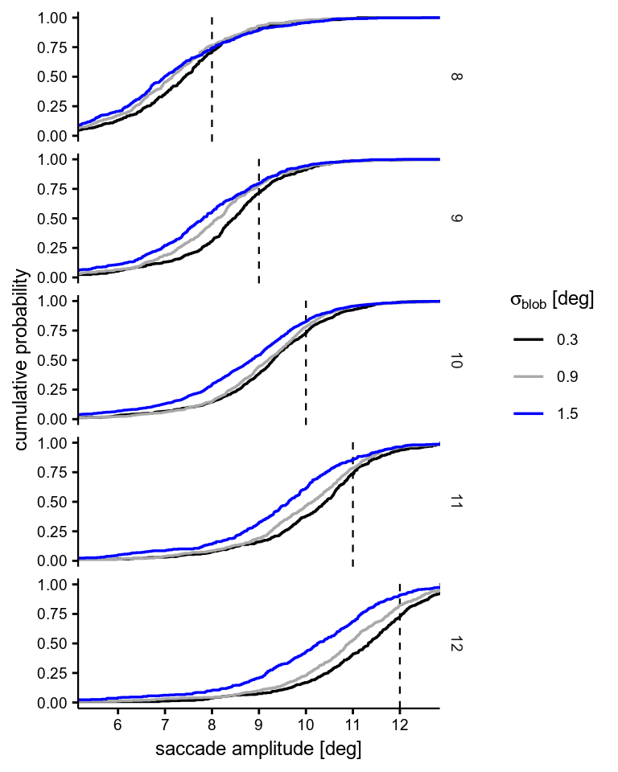

Average saccade amplitudes

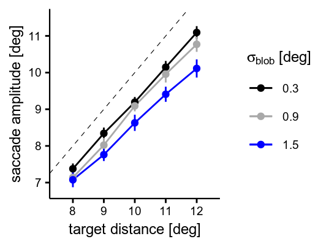

Variability of saccade amplitude gain

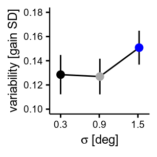

Saccade gain as a function of saccadic latency. Horizontal coordinates are computed by splitting the data according to the quartile of the latency distributions of each observer (for each observer I compute the mean latency in each quartile, then average the results across observers).

```r
# This assign each observation to a quartile of individual latency distribution
d$RTbin <- NA
d$RTbin_mean <- NA
for(i in unique(d$id)){
for(s_i in unique(d$sigmaf)){
    d$RTbin[d$id==i & d$sigmaf==s_i]<-cut(d$sacRT[d$id==i & d$sigmaf==s_i],breaks=quantile(d$sacRT[d$id==i & d$sigmaf==s_i]),labels=c("1st quartile","2nd quartile","3rd quartile","4th quartile"),names=T)
    for(q_i in unique(d$RTbin[d$id==i & d$sigmaf==s_i])){
        d$RTbin_mean[d$id==i & d$RTbin==q_i & d$sigmaf==s_i] <- mean(d$sacRT[d$id==i & d$RTbin==q_i & d$sigmaf==s_i],na.rm=T)
    }
}
}
```

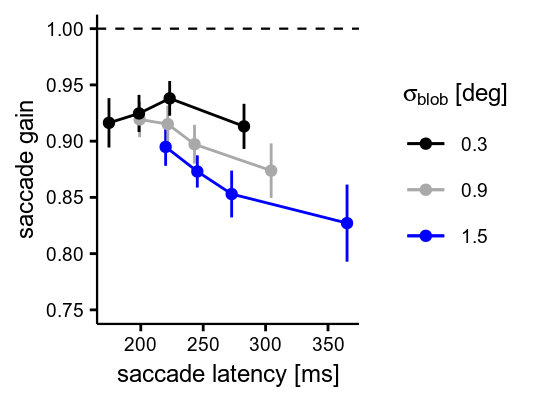

## Statistical analyses

### Positional uncertainty increases saccade variability and hypometria

Same as reported in article. Repeated-measures ANOVA on average saccade variability.

```r
summary(aov(gain~sigmaf+Error(id/sigmaf), aggregate(gain~sigmaf+sigma+id, d, sd)))
```

```
##
## Error: id
##           Df  Sum Sq  Mean Sq F value Pr(>F)
## Residuals 11 0.08768 0.007971
##
## Error: id:sigmaf
##           Df   Sum Sq   Mean Sq F value Pr(>F)
## sigmaf     2 0.004272 0.0021360   5.663 0.0104 *
## Residuals 22 0.008298 0.0003772
## ---
## Signif. codes:  0 '***' 0.001 '**' 0.01 '*' 0.05 '.' 0.1 ' ' 1
```

Linear mixed-effect model fit on saccade amplitudes.

```r
library(lme4)
m1 <- lmer(sacXresp ~ tarX * sigmaf + (tarX + sigmaf |id), d)
summary(m1)
```

```
## Linear mixed model fit by REML ['lmerMod']
## Formula: sacXresp ~ tarX * sigmaf + (tarX + sigmaf | id)
##    Data: d
##
## REML criterion at convergence: 24969.7
##
## Scaled residuals:
##     Min      1Q  Median      3Q     Max
## -6.7564 -0.4911  0.0418  0.5585  5.2160
##
## Random effects:
##  Groups   Name        Variance Std.Dev. Corr
##  id       (Intercept) 3.22189  1.7950
##           tarX        0.03358  0.1832   -0.97
##           sigmaf0.9   0.12905  0.3592    0.07 -0.07
##           sigmaf1.5   0.20854  0.4567    0.06 -0.03  0.98
##  Residual             1.90757  1.3811
## Number of obs: 7129, groups:  id, 12
##
## Fixed effects:
##                Estimate Std. Error t value
## (Intercept)    -0.10853    0.56346  -0.193
## tarX            0.93335    0.05728  16.294
## sigmaf0.9      -0.06214    0.32848  -0.189
## sigmaf1.5       1.08769    0.33924   3.206
## tarX:sigmaf0.9 -0.01464    0.03094  -0.473
## tarX:sigmaf1.5 -0.17152    0.03103  -5.527
##
## Correlation of Fixed Effects:
##             (Intr) tarX   sgm0.9 sgm1.5 tX:0.9
## tarX        -0.970
## sigmaf0.9   -0.242  0.232
## sigmaf1.5   -0.232  0.235  0.556
## trX:sgmf0.9  0.273 -0.269 -0.941 -0.454
## trX:sgmf1.5  0.272 -0.268 -0.468 -0.914  0.497
```

Correlation between changes in variability and undershoot bias across observers.

```r
# the change in undershoot bias is measured by the change in the LMM linear coefficient for each participants
gain_change <- fixef(m1)[6]+ranef(m1)$id[,4]

# sanity check: OK
#all(aggregate(gain ~ sigmaf+id, d[d$sigmaf=="1.5",],  sd)$id==row.names(ranef(m1)$id))

# the difference in variability is measured by the difference in variance between sigma=1.5 and sigma=0.3
var_increase <- aggregate(gain ~ sigmaf+id, d[d$sigmaf=="1.5",],  var)$gain - aggregate(gain ~ sigmaf+id, d[d$sigmaf=="0.3",],  var)$gain

# Pearson correlation
cor.test(var_increase, gain_change)
```

```
##
##  Pearson's product-moment correlation
##
## data:  var_increase and gain_change
## t = -3.3586, df = 10, p-value = 0.007259
## alternative hypothesis: true correlation is not equal to 0
## 95 percent confidence interval:
##  -0.9182778 -0.2648212
## sample estimates:
##        cor
## -0.7280698
```

Analysis of saccade latency: first split the data according to the quartiles of individual saccade latencies, then run ANOVA test.

```r
# ANOVA with gain as dependent variable
dag <- aggregate(gain ~ sigmaf+id + RTbin , d,  mean)
dag$RTbin <- factor(dag$RTbin)
summary(aov(gain~sigmaf*RTbin + Error(id/(sigmaf*RTbin)), dag ))
```

```
##
## Error: id
##           Df Sum Sq Mean Sq F value Pr(>F)
## Residuals 11 0.4312  0.0392
##
## Error: id:sigmaf
##           Df  Sum Sq Mean Sq F value   Pr(>F)
## sigmaf     2 0.09187 0.04594   16.21 4.71e-05 ***
## Residuals 22 0.06233 0.00283
## ---
## Signif. codes:  0 '***' 0.001 '**' 0.01 '*' 0.05 '.' 0.1 ' ' 1
##
## Error: id:RTbin
##           Df  Sum Sq  Mean Sq F value Pr(>F)
## RTbin      3 0.03152 0.010506   2.396 0.0859 .
## Residuals 33 0.14471 0.004385
## ---
## Signif. codes:  0 '***' 0.001 '**' 0.01 '*' 0.05 '.' 0.1 ' ' 1
##
## Error: id:sigmaf:RTbin
##              Df  Sum Sq  Mean Sq F value Pr(>F)
## sigmaf:RTbin  6 0.01842 0.003069   2.685 0.0215 *
## Residuals    66 0.07544 0.001143
## ---
## Signif. codes:  0 '***' 0.001 '**' 0.01 '*' 0.05 '.' 0.1 ' ' 1
```

```r
# ANOVA with gain SD as dependent variable
dag <- aggregate(gain ~ sigmaf+id + RTbin , d,  sd)
dag$RTbin <- factor(dag$RTbin)
summary(aov(gain~sigmaf*RTbin + Error(id/(sigmaf*RTbin)), dag ))
```

```
##
## Error: id
##           Df Sum Sq Mean Sq F value Pr(>F)
## Residuals 11 0.3035 0.02759
##
## Error: id:sigmaf
##           Df  Sum Sq  Mean Sq F value  Pr(>F)
## sigmaf     2 0.01653 0.008263   7.415 0.00346 **
## Residuals 22 0.02452 0.001114
## ---
## Signif. codes:  0 '***' 0.001 '**' 0.01 '*' 0.05 '.' 0.1 ' ' 1
##
## Error: id:RTbin
##           Df  Sum Sq  Mean Sq F value  Pr(>F)
## RTbin      3 0.01429 0.004762   5.094 0.00524 **
## Residuals 33 0.03085 0.000935
## ---
## Signif. codes:  0 '***' 0.001 '**' 0.01 '*' 0.05 '.' 0.1 ' ' 1
##
## Error: id:sigmaf:RTbin
##              Df   Sum Sq   Mean Sq F value Pr(>F)
## sigmaf:RTbin  6 0.004445 0.0007408   1.555  0.174
## Residuals    66 0.031437 0.0004763
```

### Saccadic range-effect

Before modelling the saccadic range effect as a function of uncertainty (see script `range_effect.R`) we check whether saccade amplitudes toward the intermediate target (at 10deg eccentricity, which was present in both sessions) are influenced by the range. This test is motivated specifically by recent studies that reported no range effect for dot-like, clearly visible targets. We do that with a two-tailed t-test.

```r
dag <- aggregate(sacXresp ~ sigmaf+sigma + session +tarX + id, d, mean)
l_sx <- with(dag,sacXresp[sigmaf=="0.3" & session=="large" & tarX==10])
s_sx <- with(dag,sacXresp[sigmaf=="0.3" & session=="small" & tarX==10])
t.test(l_sx-s_sx, var.equal=T)
```

```
##
##  One Sample t-test
##
## data:  l_sx - s_sx
## t = -0.58715, df = 11, p-value = 0.569
## alternative hypothesis: true mean is not equal to 0
## 95 percent confidence interval:
##  -0.4211748  0.2437848
## sample estimates:
##   mean of x
## -0.08869501
```

The test is not significant, indicating that a range-effect is not present when uncertainty is small (i.e., when $sigma=0.3$). We can check whether the range-effect, as measured by the differences across sessions in the amplitudes of saccades made to the 10 deg target, varies with $sigma$. We use a repeated-measures ANOVA.

```r
summary(aov(sacXresp ~ sigma*session + Error(id/(sigmaf*session)), dag[dag$tarX==10,]))
```

```
##
## Error: id
##           Df Sum Sq Mean Sq F value Pr(>F)
## Residuals 11  21.98   1.998
##
## Error: id:sigmaf
##           Df Sum Sq Mean Sq F value  Pr(>F)
## sigma      1  3.638   3.638   19.67 0.00019 ***
## Residuals 23  4.254   0.185
## ---
## Signif. codes:  0 '***' 0.001 '**' 0.01 '*' 0.05 '.' 0.1 ' ' 1
##
## Error: id:session
##           Df Sum Sq Mean Sq F value Pr(>F)
## session    1  0.021  0.0209   0.056  0.818
## Residuals 11  4.135  0.3759
##
## Error: id:sigmaf:session
##               Df Sum Sq Mean Sq F value   Pr(>F)
## sigma:session  1 0.4232  0.4232   15.05 0.000759 ***
## Residuals     23 0.6468  0.0281
## ---
## Signif. codes:  0 '***' 0.001 '**' 0.01 '*' 0.05 '.' 0.1 ' ' 1
```

The ANOVA indicates an interaction between $sigma$ (three levels, 0.3, 0.9 and 1.5 deg) and the session (large vs. small eccentricity range). The same analysis was run on the data from Experiment 3 (not shown here).